# R Notebook

Load scripts

```r
library(knitr)
source("./Scripts/Settings.R")
source("./Scripts/AusWeather.R")
source("./Scripts/Utility.R")
library(recipes)
aus_map <- function(data) {

    map <- with_nameSpace(
        "maps",
        ggplot2::borders("world", regions = "Australia",  fill = "grey90", colour = "black")
    )

    ggplot(data) + map  + xlim(112, 155) + ylim(-44, -10)  # Set y axis limits
}
aus_dark_map <- function(data) {

    map <- with_nameSpace(
        "maps",
        ggplot2::borders("world", regions = "Australia",  fill = "DarkGrey", colour = "black")
    )

    ggplot(data) + map  + xlim(112, 155) + ylim(-44, -10)  # Set y axis limits
}
```

## Degenerate Stations

Get rainfall summary

```r
rainfall_complete_stations <- aus_load_stations(aus_rainfall_station_info)
rainfall_complete_summary <-
    aus_observation_summaries(aus_rainfall_observations_info)
rainfall_complete_all_summary <-
    rainfall_complete_summary %>%
    unnest(All) %>%
    mutate('N %'= (N / (N_Year * 365)) * 100, `NA %` = (N_NA / N) * 100, 'Zero %' = (N_Zero / (N_Zero + N_NonZero)) * 100) %>%
    inner_join(select(rainfall_complete_stations, Zone, Station, Latitude, Longitude) , by = c("Zone","Station"))
rainfall_good_stations_code <-
    rainfall_complete_all_summary %>%
    filter(Status == "Good") %>%  # We actually need data
    filter(between(Longitude, 112, 155), between(Latitude, -44, -10)) %>% # Strip out all the remote islands.
    filter(N_NonZero > 0) %>% # If their are *no* recordings assume an outlier
    filter(N_Year >= 25) %>% # We need at least 20 years of data
    filter(`NA %` >= 25) %>% # We need more than 25% of data points filled
    pull(Station)
rainfall_good_stations <- rainfall_complete_stations %>% filter(Station %in% rainfall_good_stations_code)
rainfall_good_summary <-
    rainfall_complete_summary %>%
    filter(Station %in% rainfall_good_stations_code) %>%
    inner_join(rainfall_good_stations, by = c("Zone","Station")) %>%
    select(Zone, Station, Name, Latitude, Longitude, everything(), -variable, -units, -Status, -Error)
rainfall_good_all_summary <-
    rainfall_good_summary %>%
    unnest(All) %>%
    select(-Decadal, -Yearly) %>%
    mutate('N %'= (N / (N_Year * 365)) * 100, `NA %` = (N_NA / N) * 100, 'Zero %' = (N_Zero / (N_Zero + N_NonZero)) * 100)
rainfall_good_all_summary
```

| Zone | Station | Name | Latitude | Longitude | N_Year | Min_Year | Max_Year | N | N_NA | N_Present | N_Zero | N_NonZero | NearZeroVar | Min | Mean | Median | Max | FirstQ | ThirdQ | SD | Skew | N % | NA % | Zero % |
| --- | --- | --- | --- | --- | --- | --- | --- | --- | --- | --- | --- | --- | --- | --- | --- | --- | --- | --- | --- | --- | --- | --- | --- | --- |
| AUS | 36085 | ABERFOYLE | -21.6678 | 145.2689 | 118 | 1892 | 2009 | 42824 | 30781 | 12043 | 11016 | 1027 | TRUE | 0 | 1.30717429 | 0.0 | 167.1 | 0 | 0.000 | 7.104882 | 9.408179 | 99.42884 | 71.87792 | 91.47222 |
| AUS | 4000 | ABYDOS | -21.4167 | 118.9333 | 58 | 1917 | 1974 | 21184 | 6570 | 14614 | 13745 | 869 | TRUE | 0 | 0.76910497 | 0.0 | 254.0 | 0 | 0.000 | 5.822163 | 17.079110 | 100.06613 | 31.01397 | 94.05365 |
| AUS | 4045 | ABYDOS WOODSTOCK | -21.6200 | 118.9550 | 97 | 1901 | 1997 | 35337 | 11604 | 23733 | 22080 | 1653 | TRUE | 0 | 0.91855644 | 0.0 | 330.2 | 0 | 0.000 | 6.581122 | 18.314338 | 99.80794 | 32.83810 | 93.03501 |
| AUS | 14244 | ACACIA HILLS | -12.7641 | 131.1598 | 25 | 1989 | 2013 | 9031 | 3083 | 5948 | 4506 | 1442 | TRUE | 0 | 4.95257229 | 0.0 | 253.0 | 0 | 0.000 | 14.315358 | 4.920070 | 98.96986 | 34.13797 | 75.75656 |
| AUS | 88119 | ACHERON RIVER @ TAGGERTY | -37.3167 | 145.7167 | 45 | 1974 | 2018 | 16351 | 8671 | 7680 | 4869 | 2811 | FALSE | 0 | 2.13964844 | 0.0 | 114.2 | 0 | 1.000 | 6.022164 | 5.628632 | 99.54947 | 53.03040 | 63.39844 |
| AUS | 30100 | ACTION DOWNS STATION | -20.5167 | 143.2833 | 53 | 1923 | 1975 | 19358 | 10926 | 8432 | 8228 | 204 | TRUE | 0 | 0.37756167 | 0.0 | 177.8 | 0 | 0.000 | 4.338237 | 20.468595 | 100.06720 | 56.44178 | 97.58065 |
| AUS | 71040 | ADAMINABY (YAOUK) | -35.7858 | 148.8106 | 48 | 1971 | 2018 | 17379 | 5337 | 12042 | 8876 | 3166 | TRUE | 0 | 2.42460555 | 0.0 | 93.6 | 0 | 0.600 | 6.779300 | 4.907319 | 99.19521 | 30.70948 | 73.70869 |
| AUS | 45043 | ADAVALE | -25.9094 | 144.5989 | 34 | 1985 | 2018 | 12163 | 3250 | 8913 | 8158 | 755 | TRUE | 0 | 1.10829126 | 0.0 | 117.0 | 0 | 0.000 | 5.682971 | 8.547778 | 98.00967 | 26.72038 | 91.52923 |
| AUS | 23001 | ADELAIDE (BRIGHTON) | -35.0199 | 138.5200 | 121 | 1898 | 2018 | 44075 | 16757 | 27318 | 19298 | 8020 | TRUE | 0 | 1.40143129 | 0.0 | 71.1 | 0 | 0.500 | 4.055837 | 5.377919 | 99.79622 | 38.01929 | 70.64207 |
| AUS | 23064 | ADELAIDE (LARGS BAY) | -34.8314 | 138.4884 | 117 | 1896 | 2012 | 42642 | 36953 | 5689 | 4096 | 1593 | TRUE | 0 | 1.06957286 | 0.0 | 36.0 | 0 | 0.300 | 3.182170 | 5.066043 | 99.85248 | 86.65869 | 71.99859 |

[output cut: 990 more lines]

List weather stations that are seem degenerate

```r
rainfall_complete_all_summary %>%
    filter(NearZeroVar) %>%
    select(Station, N_Year, N, `NA %`, 'Zero %') %>%
    sample_n(20)
```

| Station | N_Year | N | NA % | Zero % |
| --- | --- | --- | --- | --- |
| 21028 | 108 | 39354 | 25.1537328 | 84.65116 |
| 39219 | 41 | 14884 | 0.6181134 | 86.54002 |
| 10902 | 21 | 7517 | 2.8601836 | 76.37634 |
| 75162 | 27 | 9709 | 1.3183644 | 85.09550 |
| 51044 | 131 | 47633 | 23.8889006 | 88.07028 |
| 78083 | 31 | 11321 | 2.6852752 | 79.51348 |
| 40488 | 37 | 13240 | 18.8972810 | 70.75806 |
| 10523 | 57 | 20758 | 9.0808363 | 78.38711 |
| 62021 | 149 | 54299 | 1.5101567 | 78.22136 |
| 60006 | 60 | 21915 | 5.8635638 | 65.47261 |

[output cut: 10 more lines]

Some stations with a very low % of NAs have lots of zeros. Huge amounts of australia is arid. Maybe thats to be expected.

Plot Zero % on map.

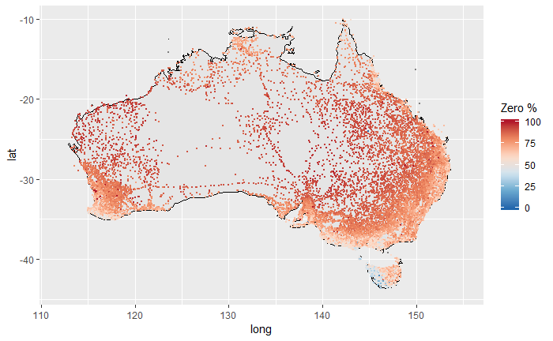

```r
rainfall_complete_all_summary %>%
    aus_map() +
    geom_point(aes(x = Longitude, y = Latitude, color = `Zero %`), size = .5) +
    scale_colour_distiller(type = "div", palette="RdBu", direction = -1)
```

Stations recording high number of zeros are in arid regions. Recording large numbers of zeros is to be expected and is informational.

Plot Na % on map.

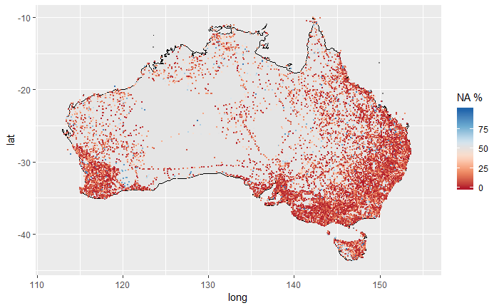

```r
rainfall_complete_all_summary %>%
    aus_map() +
    geom_point(aes(x = Longitude, y = Latitude, color = `NA %`), size = .5) +
    scale_colour_distiller(type = "div", palette="RdBu", direction = 1)
```

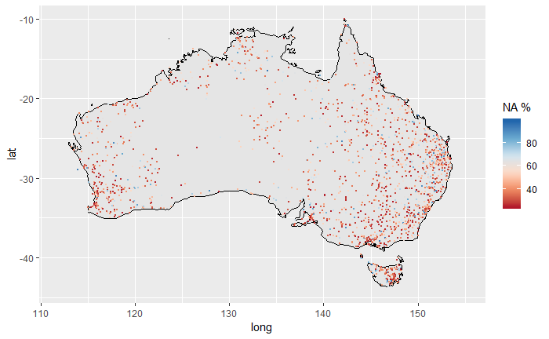

```r
rainfall_good_all_summary %>%
    aus_map() +
    geom_point(aes(x = Longitude, y = Latitude, color = `NA %`), size = .5) +
    scale_colour_distiller(type = "div", palette="RdBu", direction = 1)
```

If we drop out stations with a low % of NAs then we get what seems to a scattering of stations across australia with a reasonble number in remote regions.

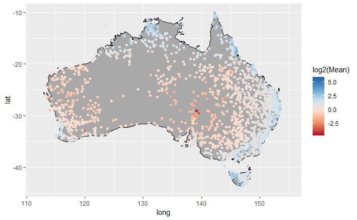

```r
rainfall_good_all_summary %>%
    aus_dark_map() +
    geom_point(aes(x = Longitude, y = Latitude, color = log2(Mean))) +
    scale_colour_distiller(type = "div", palette="RdBu", direction = 1)
```

## Samples Stations

Lets determine a random selection of stations to explore.

Pick a random set then use max dissimlarity to detect unusual samples.

```r
# Choose a selection of statistics used to select a sample
sample_prep <-
    rainfall_good_all_summary %>%
    select(N_Year, Min_Year, Latitude, Longitude, N, 'N %','NA %', 'Zero %', Min, Mean, Max, SD, Skew)
# Center and scale all properties
sample_prep <- recipe(sample_prep) %>% step_center(everything()) %>% step_scale(everything()) %>% prep(retain = TRUE) %>% juice()
# Choose an initial random set of 5 and a further 15 records that have max disimilarity
set.seed(101)
sample_initial_idx <- sample(1:nrow(sample_prep), 5)
sample_dissim_idx <- caret::maxDissim(sample_prep[sample_initial_idx,], sample_prep, n = 20, verbose = FALSE)
sample_all_summary <- rainfall_good_all_summary[c(sample_initial_idx, sample_dissim_idx),]
sample_stations <- rainfall_complete_stations %>% filter(Station %in% sample_all_summary$Station)
sample_summary <- rainfall_good_summary %>% filter(Station %in% sample_all_summary$Station)
sample_all_summary <- sample_all_summary %>% select(Station, Latitude, Longitude, N_Year, Min_Year, Max_Year, N, 'N %', 'NA %', 'Zero %', Min, Mean, Max, SD, Skew)
sample_all_summary
```

| Station | Latitude | Longitude | N_Year | Min_Year | Max_Year | N | N % | NA % | Zero % | Min | Mean | Max | SD | Skew |
| --- | --- | --- | --- | --- | --- | --- | --- | --- | --- | --- | --- | --- | --- | --- |
| 72020 | -35.5167 | 148.0500 | 37 | 1936 | 1972 | 13454 | 99.62236 | 51.59061 | 67.465070 | 0 | 3.1175802 | 133.9 | 8.085677 | 4.645340 |
| 14173 | -13.3787 | 131.5049 | 50 | 1968 | 2017 | 17929 | 98.24110 | 52.56289 | 78.988830 | 0 | 3.9229394 | 255.0 | 12.987892 | 6.728322 |
| 22840 | -35.7364 | 136.9967 | 39 | 1961 | 1999 | 13999 | 98.34211 | 35.35253 | 66.265193 | 0 | 2.1052376 | 94.0 | 5.549151 | 5.146421 |
| 3020 | -18.4922 | 124.3992 | 83 | 1935 | 2017 | 30316 | 100.06932 | 59.67146 | 90.250286 | 0 | 1.8579339 | 254.0 | 9.535214 | 10.428540 |
| 7022 | -27.4667 | 117.8500 | 58 | 1896 | 1953 | 20971 | 99.05999 | 27.85752 | 90.111706 | 0 | 0.5622381 | 138.7 | 3.496698 | 14.385771 |
| 31141 | -17.2639 | 145.8536 | 46 | 1973 | 2018 | 16679 | 99.33889 | 28.86864 | 53.860418 | 0 | 30.5056220 | 1947.0 | 88.003010 | 7.043665 |
| 94092 | -42.9275 | 147.1839 | 35 | 1962 | 1996 | 12723 | 99.59295 | 93.36634 | 4.265403 | 0 | 50.6186019 | 261.0 | 47.126349 | 1.911272 |
| 97076 | -43.1867 | 146.6636 | 29 | 1986 | 2014 | 10470 | 98.91356 | 85.51098 | 58.338827 | 0 | 24.5754120 | 270.0 | 45.107187 | 2.347512 |
| 14224 | -13.8062 | 132.1970 | 36 | 1983 | 2018 | 13065 | 99.42922 | 41.05626 | 73.341125 | 0 | 3.8111414 | 1052.2 | 16.357948 | 35.854728 |
| 31064 | -16.9083 | 145.8886 | 117 | 1894 | 2010 | 42399 | 99.28346 | 25.46994 | 61.041139 | 0 | 7.5351899 | 778.5 | 24.052751 | 7.938190 |

[output cut: 15 more lines]

Stations have measurments for almost every day they are considered to have a record for. Neat.

# Sample Exploration

Plot locations of samples

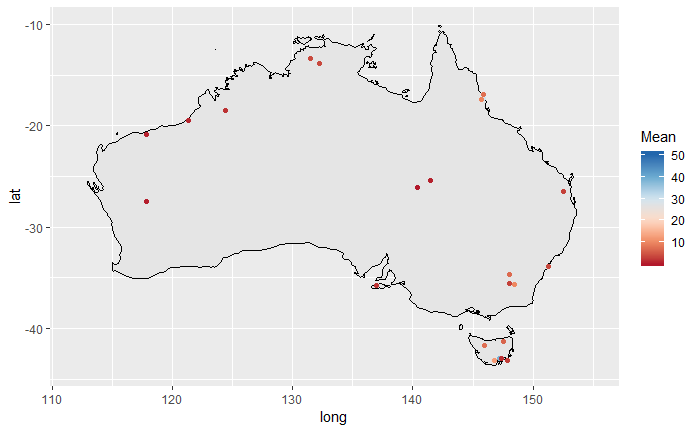

```r
sample_all_summary %>%
    aus_map() +
    geom_point(aes(x = Longitude, y = Latitude, color = Mean)) +
    scale_colour_distiller(type = "div", palette="RdBu", direction = 1)
```

## Yearly Exploration

Plot number of observations per year across time.

```r
sample_complete_yearly_summary <-
    sample_summary %>%
    unnest(Yearly) %>%
    mutate('N %'= (N / 365) * 100, `Present %` = (N_Present / N) * 100, 'Zero %' = (N_Zero / (N_Zero + N_NonZero)) * 100)
```

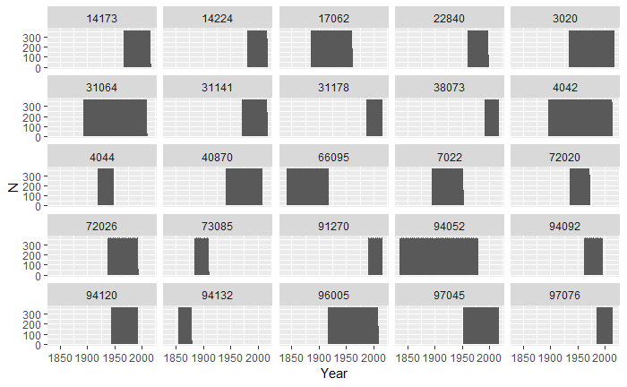

```r
sample_complete_yearly_summary %>% ggplot() + geom_col(aes(x = Year, y = N)) + facet_wrap(~ Station)
```

All the records are in solid blocks. There are no drop outs for stations in the records we have.

Plot % of NA of observations per year across time.

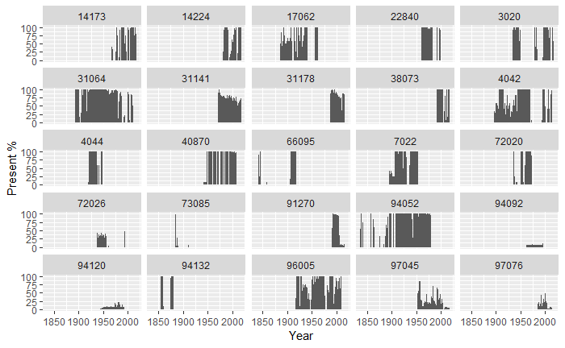

```r
sample_complete_yearly_summary %>% ggplot() + geom_col(aes(x = Year, y = `Present %`)) + facet_wrap(~ Station)
```

However the record keeping reliability of some stations is highly erratic. They often go through periods of not keeping data.

Plot % of Zero observations per year across time.

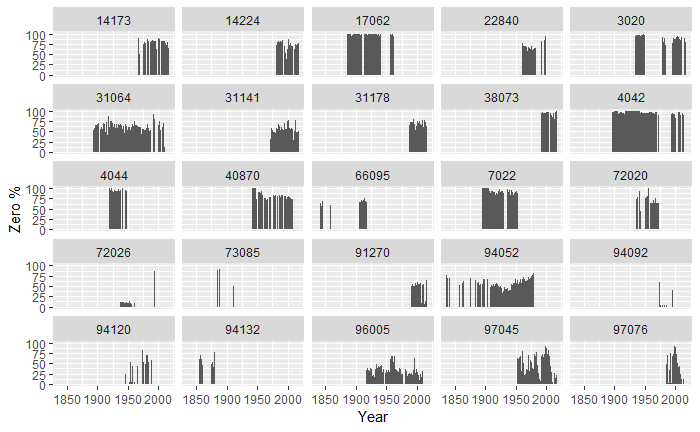

```r
sample_complete_yearly_summary %>% ggplot() + geom_col(aes(x = Year, y = `Zero %`)) + facet_wrap(~ Station)
```

Same story.The number of zeros recorded is inconsistent. Some years seem to have no data at all and thus we can’t even calc a zero%.

Plot mean of observations per year across time. This is the sort of figure we will be interested in.

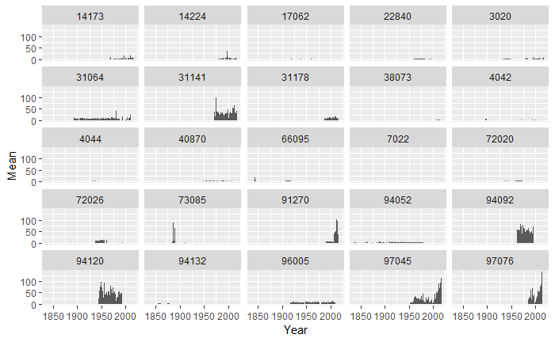

```r
sample_complete_yearly_summary %>% ggplot() + geom_col(aes(x = Year, y = Mean)) + facet_wrap(~ Station)
```

It looks way too erractic for some stations.

## Years with complete records.

To be included a year must have at least 25% of records recorded.

```r
sample_yearly_summary <-
    sample_summary %>%
    unnest(Yearly) %>%
    mutate('N %'= (N / 365) * 100, `Present %` = (N_Present / N) * 100, 'Zero %' = (N_Zero / (N_Zero + N_NonZero)) * 100) %>%
    filter(`Present %` >= 25, N >= 360)
```

Now plot number of observations per year. We now expect gaps.

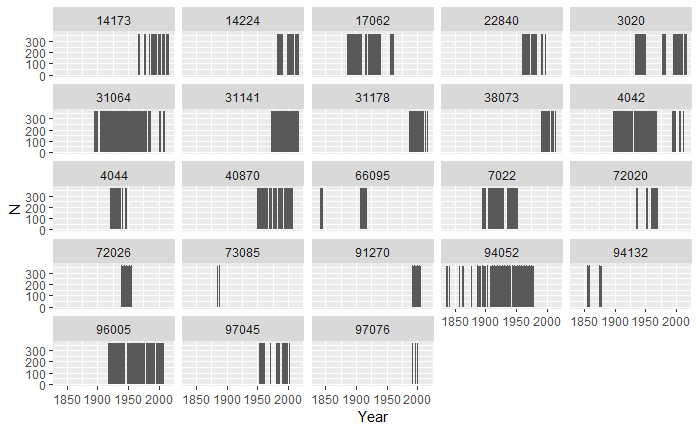

```r
sample_yearly_summary %>% ggplot() + geom_col(aes(x = Year, y = N)) + facet_wrap(~ Station)
```

Now plot % of Present observations per year across time. Years should an observable signal or be dropped out.

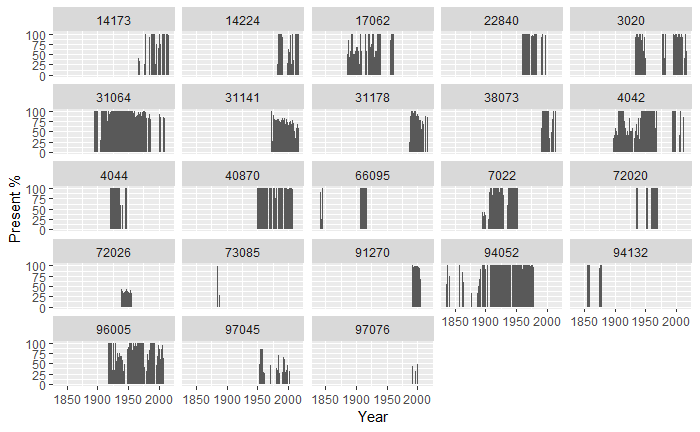

```r
sample_yearly_summary %>% ggplot() + geom_col(aes(x = Year, y = `Present %`)) + facet_wrap(~ Station)
```

Plot % of Zero observations per year across time.

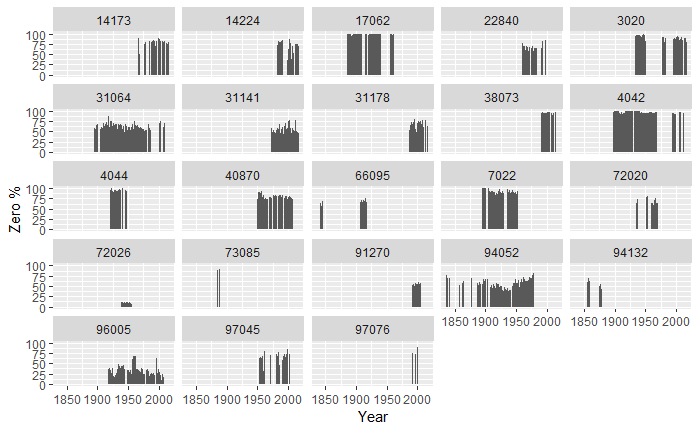

```r
sample_yearly_summary %>% ggplot() + geom_col(aes(x = Year, y = `Zero %`)) + facet_wrap(~ Station)
```

Okay we have either a measure for a year or the year is dropped out entirely and the number of days per year where a zero was recorded looks consistent for each station over time.

A possibly exception if 96005.

Also some station have had their years almost entirely dropped out.

Really the important measure is mean rainfall per year.

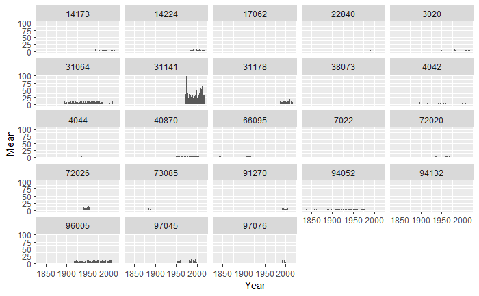

```r
sample_yearly_summary %>% ggplot() + geom_col(aes(x = Year, y = Mean)) + facet_wrap(~ Station)
```

Lets drop station 31141 from our plot so we can focus on the remaining stations.

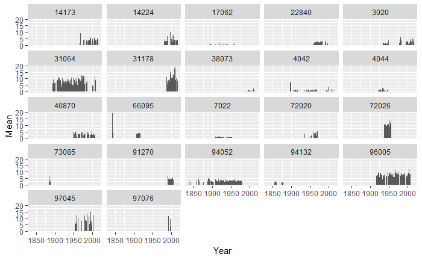

```r
sample_yearly_summary %>% filter(Station != '31141') %>% ggplot() + geom_col(aes(x = Year, y = Mean)) + facet_wrap(~ Station)
```

The means look more consistent over time but there may be some possible outliers.

Bouts of extreme weather are to be expected. Also we selected these stations as being odd.

## Stations with consistent records.

Lets filter our list down to stations that have a least 30 years of data where each year has at least 25% of days having an observation.

```r
consistent_year_cutoff <- 0.25
rainfall_station_consistency  <-
    rainfall_good_summary %>%
    unnest(Yearly) %>%
    mutate(Present_Ratio = N_Present / N) %>%
    filter(N > 350, Present_Ratio > consistent_year_cutoff) %>%
    group_by(Zone, Station) %>%
    summarise(N_consistent = n())
rainfall_consistency_summary <-
    rainfall_complete_summary %>%
    left_join(rainfall_station_consistency, by=c("Zone", "Station")) %>%
    unnest(All) %>%
    mutate(N_Consistent = ifelse(!is.na(N_consistent), N_consistent, 0)) %>%
    mutate(Present_Ratio = N_Present / N) %>%
    select(
        Zone, Station, Status, N_Year, N_Consistent, Min_Year, Max_Year,
        N, N_NA, N_Present, Present_Ratio)
rainfall_consistent_station_codes <- rainfall_consistency_summary %>% filter(N_Consistent > 30) %>% pull(Station)
rainfall_consistent_stations <- rainfall_complete_stations %>% filter(Station %in% rainfall_consistent_station_codes)
rainfall_consistent_all_summary <-
    rainfall_complete_summary %>%
    inner_join(rainfall_consistent_stations, by = c("Zone","Station")) %>%
    left_join(rainfall_station_consistency, by=c("Zone", "Station")) %>%
    mutate(N_Consistent = ifelse(!is.na(N_consistent), N_consistent, 0)) %>%
    unnest(All) %>%
    select(-Decadal, -Yearly) %>%
    mutate(Present_Ratio = N_Present / N) %>%
    select(Zone, Station, Name, Latitude, Longitude,
           N_Year, N_Consistent, Min_Year, Max_Year,
           N, N_NA, N_Present, Present_Ratio, Min, Mean, Max, FirstQ, Median, ThirdQ, SD, Skew)
rainfall_consistent_all_summary
```

| Zone | Station | Name | Latitude | Longitude | N_Year | N_Consistent | Min_Year | Max_Year | N | N_NA | N_Present | Present_Ratio | Min | Mean | Max | FirstQ | Median | ThirdQ | SD | Skew |
| --- | --- | --- | --- | --- | --- | --- | --- | --- | --- | --- | --- | --- | --- | --- | --- | --- | --- | --- | --- | --- |
| AUS | 36085 | ABERFOYLE | -21.6678 | 145.2689 | 118 | 35 | 1892 | 2009 | 42824 | 30781 | 12043 | 0.2812208 | 0 | 1.30717429 | 167.1 | 0 | 0.0 | 0.000 | 7.104882 | 9.408179 |
| AUS | 4000 | ABYDOS | -21.4167 | 118.9333 | 58 | 47 | 1917 | 1974 | 21184 | 6570 | 14614 | 0.6898603 | 0 | 0.76910497 | 254.0 | 0 | 0.0 | 0.000 | 5.822163 | 17.079110 |
| AUS | 4045 | ABYDOS WOODSTOCK | -21.6200 | 118.9550 | 97 | 71 | 1901 | 1997 | 35337 | 11604 | 23733 | 0.6716190 | 0 | 0.91855644 | 330.2 | 0 | 0.0 | 0.000 | 6.581122 | 18.314338 |
| AUS | 30100 | ACTION DOWNS STATION | -20.5167 | 143.2833 | 53 | 47 | 1923 | 1975 | 19358 | 10926 | 8432 | 0.4355822 | 0 | 0.37756167 | 177.8 | 0 | 0.0 | 0.000 | 4.338237 | 20.468595 |
| AUS | 71040 | ADAMINABY (YAOUK) | -35.7858 | 148.8106 | 48 | 33 | 1971 | 2018 | 17379 | 5337 | 12042 | 0.6929052 | 0 | 2.42460555 | 93.6 | 0 | 0.0 | 0.600 | 6.779300 | 4.907319 |
| AUS | 23001 | ADELAIDE (BRIGHTON) | -35.0199 | 138.5200 | 121 | 75 | 1898 | 2018 | 44075 | 16757 | 27318 | 0.6198071 | 0 | 1.40143129 | 71.1 | 0 | 0.0 | 0.500 | 4.055837 | 5.377919 |
| AUS | 23037 | ADELAIDE (PARAFIELD PLANT INTRODUCTION C | -34.7833 | 138.6242 | 89 | 51 | 1907 | 1995 | 32323 | 14290 | 18033 | 0.5578999 | 0 | 1.34258859 | 81.5 | 0 | 0.0 | 0.500 | 3.921837 | 5.988539 |
| AUS | 14000 | ADELAIDE RIVER RAILWAY | -13.2467 | 131.1117 | 46 | 34 | 1926 | 1971 | 16467 | 5622 | 10845 | 0.6585899 | 0 | 3.62028585 | 180.3 | 0 | 0.0 | 0.000 | 11.338642 | 5.158695 |
| AUS | 36083 | ALBRO STATION | -22.7044 | 146.5694 | 49 | 36 | 1970 | 2018 | 17588 | 5598 | 11990 | 0.6817148 | 0 | 1.64281902 | 171.4 | 0 | 0.0 | 0.000 | 7.660087 | 8.043908 |
| AUS | 37109 | ALDERLEY STATION | -22.4936 | 139.6615 | 99 | 31 | 1920 | 2018 | 35960 | 25338 | 10622 | 0.2953838 | 0 | 0.80353982 | 186.4 | 0 | 0.0 | 0.000 | 5.188920 | 13.095335 |

[output cut: 990 more lines]

Yearly consistent summary

```r
rainfall_consistent_yearly_summary <-
    rainfall_complete_summary %>%
    inner_join(rainfall_consistent_stations, by = c("Zone","Station")) %>%
    left_join(rainfall_station_consistency, by=c("Zone", "Station")) %>%
    mutate(N_Consistent = ifelse(!is.na(N_consistent), N_consistent, 0)) %>%
    unnest(Yearly) %>%
    mutate(Present_Ratio = N_Present / N) %>%
    filter(N > 350, Present_Ratio > consistent_year_cutoff) %>%
    select(Zone, Station, Name, Latitude, Longitude,
           Year, N_Year, N_Consistent, Min_Year, Max_Year,
           N, N_NA, N_Present, Present_Ratio, Min, Mean, Max, FirstQ, Median, ThirdQ, SD, Skew)
rainfall_consistent_yearly_summary
```

| Zone | Station | Name | Latitude | Longitude | Year | N_Year | N_Consistent | Min_Year | Max_Year | N | N_NA | N_Present | Present_Ratio | Min | Mean | Max | FirstQ | Median | ThirdQ | SD | Skew |
| --- | --- | --- | --- | --- | --- | --- | --- | --- | --- | --- | --- | --- | --- | --- | --- | --- | --- | --- | --- | --- | --- |
| AUS | 36085 | ABERFOYLE | -21.6678 | 145.2689 | 1892 | 118 | 35 | 1892 | 2009 | 366 | 246 | 120 | 0.3278689 | 0 | 0.00000000 | 0.0 | 0 | 0 | 0.000 | 0.0000000 | NaN |
| AUS | 36085 | ABERFOYLE | -21.6678 | 145.2689 | 1901 | 118 | 35 | 1892 | 2009 | 365 | 92 | 273 | 0.7479452 | 0 | 0.48095238 | 26.4 | 0 | 0 | 0.000 | 2.4827944 | 6.780120 |
| AUS | 36085 | ABERFOYLE | -21.6678 | 145.2689 | 1969 | 118 | 35 | 1892 | 2009 | 365 | 0 | 365 | 1.0000000 | 0 | 0.67589041 | 77.5 | 0 | 0 | 0.000 | 4.7120047 | 12.714277 |
| AUS | 36085 | ABERFOYLE | -21.6678 | 145.2689 | 1970 | 118 | 35 | 1892 | 2009 | 365 | 0 | 365 | 1.0000000 | 0 | 0.74273973 | 43.2 | 0 | 0 | 0.000 | 3.8497514 | 7.309766 |
| AUS | 36085 | ABERFOYLE | -21.6678 | 145.2689 | 1971 | 118 | 35 | 1892 | 2009 | 365 | 0 | 365 | 1.0000000 | 0 | 1.84027397 | 133.4 | 0 | 0 | 0.000 | 9.7250749 | 9.138750 |
| AUS | 36085 | ABERFOYLE | -21.6678 | 145.2689 | 1972 | 118 | 35 | 1892 | 2009 | 366 | 0 | 366 | 1.0000000 | 0 | 0.93060109 | 84.6 | 0 | 0 | 0.000 | 5.4699020 | 10.901664 |
| AUS | 36085 | ABERFOYLE | -21.6678 | 145.2689 | 1973 | 118 | 35 | 1892 | 2009 | 365 | 0 | 365 | 1.0000000 | 0 | 1.57835616 | 77.0 | 0 | 0 | 0.000 | 6.4485153 | 6.718269 |
| AUS | 36085 | ABERFOYLE | -21.6678 | 145.2689 | 1974 | 118 | 35 | 1892 | 2009 | 365 | 0 | 365 | 1.0000000 | 0 | 2.76000000 | 128.2 | 0 | 0 | 0.000 | 11.0831939 | 6.554622 |
| AUS | 36085 | ABERFOYLE | -21.6678 | 145.2689 | 1975 | 118 | 35 | 1892 | 2009 | 365 | 0 | 365 | 1.0000000 | 0 | 1.89698630 | 50.0 | 0 | 0 | 0.000 | 6.9111088 | 4.438630 |
| AUS | 36085 | ABERFOYLE | -21.6678 | 145.2689 | 1976 | 118 | 35 | 1892 | 2009 | 366 | 0 | 366 | 1.0000000 | 0 | 1.41748634 | 60.0 | 0 | 0 | 0.000 | 6.1566866 | 6.060179 |

[output cut: 990 more lines]

## Consistent exploration

Map of Log2 means

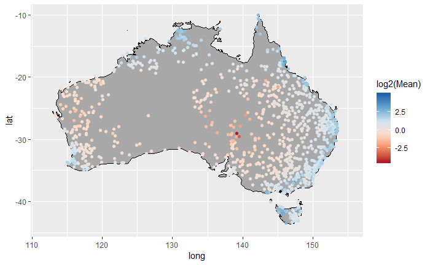

```r
rainfall_consistent_all_summary %>%
    aus_dark_map() +
    geom_point(aes(x = Longitude, y = Latitude, color = log2(Mean))) +
    scale_colour_distiller(type = "div", palette="RdBu", direction = 1)
```

I can see the rainfall by regions. You can see east of the great divde. Northern Australia, the deserts. Looking good.

## Exploration over time

Lets get a sample of consistent stations to explore.

```r
# Choose a selection of statistics used to select a sample
consistent_sample_prep <-
    rainfall_consistent_all_summary %>%
    select(N_Year, N_Consistent, Min_Year, N, Present_Ratio, Min, Mean, Max, SD, Skew)
# Center and scale all properties
consistent_sample_prep <- recipe(consistent_sample_prep) %>% step_center(everything()) %>% step_scale(everything()) %>% prep(retain = TRUE) %>% juice()
# Choose an initial random set of 5 and a further 15 records that have max disimilarity
set.seed(103)
consistent_sample_initial_idx <- sample(1:nrow(consistent_sample_prep), 5)
consistent_sample_dissim_idx <- caret::maxDissim(consistent_sample_prep[consistent_sample_initial_idx,], consistent_sample_prep, n = 20, verbose = FALSE)
consistent_sample_idx <- c(consistent_sample_initial_idx, consistent_sample_dissim_idx)
consistent_sample_all_summary <- rainfall_consistent_all_summary[consistent_sample_idx,]
consisten_sample_stations <- rainfall_complete_stations %>% filter(Station %in% consistent_sample_all_summary$Station)
consistent_sample_yearly_summary <- rainfall_consistent_yearly_summary %>% filter(Station %in% consistent_sample_all_summary$Station)
```

### Number of Records per year

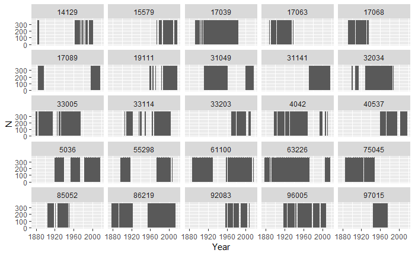

```r
consistent_sample_yearly_summary %>% ggplot() + geom_col(aes(x = Year, y = N)) + facet_wrap(~ Station)
```

We now tend to have more complete records.

### Number of Observations per year

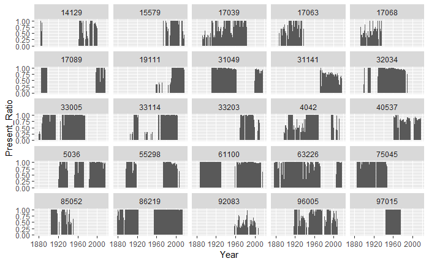

```r
consistent_sample_yearly_summary %>% ggplot() + geom_col(aes(x = Year, y = Present_Ratio)) + facet_wrap(~ Station)
```

Much more consistent presence ratio.

### Mean per year

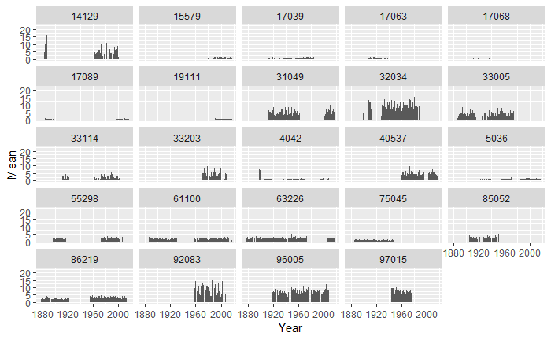

```r
consistent_sample_yearly_summary %>% filter(Station != "31141") %>% ggplot() + geom_col(aes(x = Year, y = Mean)) + facet_wrap(~ Station)
```